# Geog533 Lab 9

Your name

Complete the following exercises in Chapter 9 (More on Regression) of the textbook pages 286-287.

## Question 1

This is Exercise 7 in Chapter 9 of the Textbook [R].

The following results were obtained from a regression of $n = 14$ housing prices (in dollars) on median family income, size of house, and size of lot:

|  | Sum of squares | df | Mean square | F |
| --- | --- | --- | --- | --- |
| Regression SS: | 4234 | 3 |  |  |
| Residual SS: | 3487 |  |  |  |
| Total SS: |  |  |  |  |

|  | Coefficient (b) | Standard error (sb) | VIF |
| --- | --- | --- | --- |
| Median family income | 1.57 | 0.34 | 1.3 |
| Size of house (sq.ft) | 23.4 | 11.2 | 2.9 |
| Size of lot (sq.ft) | -9.5 | 7.1 | 11.3 |
| Constant | 40,000 | 1000 |  |

### Question 1(a)

Fill in the blanks.

```r
ssm <- 4234
ssr <- 3487
n <- 14
sst <- ssr + ssm
dft <- 14 - 1
dfr <- dft - 3
msm <- ssm/3
msr <- ssr/dfr
f <- msm/msr
```

|  | Sum of squares | Degrees of freedom | Mean square | *F* |
| --- | --- | --- | --- | --- |
| Regression | 4234 | 3 | 1411.3333333 | 4.0474142 |
| Residual | 3487 | 10 | 348.7 |  |
| Total | 7721 | 13 |  |  |

### Question 1(b)

What is the value of $r^2$?

```r
r_square <- ssm/sst
r_square
```

```
[1] 0.5483746
```

```r
#r2 is 0.5484
```

### Question 1(c)

What is the standard error of the estimate?

```r
sd <- sqrt(msr)
sd
```

```
[1] 18.67351
```

```r
# standard error is 18.67351
```

### Question 1(d)

Test the null hypothesis that $R^2 = 0$ by comparing the $F-statistic$ from the table with its critical value.

```r
f_c <- qf(0.95,df1 = 3,df2 = 10)
if(f > f_c){
  print("we reject non hypothesis, the R2 is significant")
}else{
  print("we can not reject non hypothesis")
}
```

```
[1] "we reject non hypothesis, the R2 is significant"
```

### Question 1(e)

Are the coefficients in the direction you would hypothesize? If not, which coefficients are opposite in sign from what you would expect?

```r
# No, the coefficient of size of lot is opposite in sign from what I expect because the housing price and lot size should have positive correlation.
```

### Question 1(f)

Find the $t-statistics$ associated with each coefficient, and test the null hypotheses that the coefficients are equal to zero. Use $ = 0.05$, and be sure to give the critical value of $t$.

```r
t1 <- 1.57/0.34
t2 <- 23.4/11.2
t3 <- -9.5/7.1
t_c_r <- qt(0.975,df = 13)
t_c_l <- qt(0.025,df = 13)
if(t1 > t_c_r){
  print("we reject non hypothesis, the coefficient of median family is not equal to zero and is significant")
}else
  print("we can not reject no hypothesis, the coefficient of median family is equal to zero.")
```

```
[1] "we reject non hypothesis, the coefficient of median family is not equal to zero and is significant"
```

```r
if(t2 > t_c_r){
  print("we reject non hypothesis, the coefficient of size of house is not equal to zero and is significant")
}else
  print("we can not reject no hypothesis, the coefficient of size of house is equal to zero.")
```

```
[1] "we can not reject no hypothesis, the coefficient of size of house is equal to zero."
```

```r
if(t3 < t_c_l){
  print("we reject non hypothesis, the coefficient of size of lot is not equal to zero and is significant.")
}else
  print("we can not reject no hypothesis, the coefficient of size of lot is equal to zero.")
```

```
[1] "we can not reject no hypothesis, the coefficient of size of lot is equal to zero."
```

### Question 1(g)

What do you conclude from the variance inflation factors (VIFs)? What (if any) modifications would you recommend in light of the VIFs?

```r
# The VIF of the Size of lot is 11.3, which is bigger than 5. This indicates potential multicollinearity problem
# So we need to remove the influence of size of lot to modify the output
```

### Question 1(h)

What is the predicted sales price of a house that is 1500 square feet, on a lot 60´×100´, and in a neighborhood where the median family income is $40,000?

```r
sales <- 40000*1.57 + 1500*23.4 + 40000
sales
```

```
[1] 137900
```

```r
# The sales is 137900
```

## Question 2

This is Exercise 10 in Chapter 9 of the Textbook [R].

### Question 2(a)

Using R and the [Hypothetical UK Housing Prices dataset](http://spatial.binghamton.edu/geog533/data/UK_Housing.csv), construct a regression equation using housing price as the dependent variable, and bedrooms, bathrooms, date built, garage, fireplace, floor area, and whether the home is detached as the independent variables. Investigate the importance of multicollinearity and outliers. Comment on the weaknesses of this specification, and on the results.

```r
url = "http://spatial.binghamton.edu/geog533/data/UK_Housing.csv"
df2 <- read.csv(file = "https://xujianzi.github.io/data/UK.csv", header = T)
m <- lm(df2$price~df2$garage+df2$bedrooms+df2$bathrooms+df2$datebuilt+df2$floorarea
        +df2$detached+df2$fireplace)
summary(m)
```

```
Call:
lm(formula = df2$price ~ df2$garage + df2$bedrooms + df2$bathrooms +
    df2$datebuilt + df2$floorarea + df2$detached + df2$fireplace)

Residuals:
   Min     1Q Median     3Q    Max
-38150  -6933  -1086   6705  64014

Coefficients:
                Estimate Std. Error
(Intercept)   -256087.18   34854.98
df2$garage      10980.77    1274.94
df2$bedrooms      686.01     742.27
df2$bathrooms    2637.29    1526.36
df2$datebuilt     130.36      17.84
df2$floorarea     374.18      22.22
df2$detached    13186.76    2346.12
df2$fireplace   -3144.39    1227.89
              t value Pr(>|t|)
(Intercept)    -7.347 8.50e-13 ***
df2$garage      8.613  < 2e-16 ***
df2$bedrooms    0.924   0.3558
df2$bathrooms   1.728   0.0846 .
df2$datebuilt   7.306 1.12e-12 ***
df2$floorarea  16.842  < 2e-16 ***
df2$detached    5.621 3.19e-08 ***
df2$fireplace  -2.561   0.0107 *
---
Signif. codes:
  0 ‘***’ 0.001 ‘**’ 0.01 ‘*’ 0.05 ‘.’
  0.1 ‘ ’ 1

Residual standard error: 11550 on 491 degrees of freedom
Multiple R-squared:  0.6967,    Adjusted R-squared:  0.6924
F-statistic: 161.1 on 7 and 491 DF,  p-value: < 2.2e-16
```

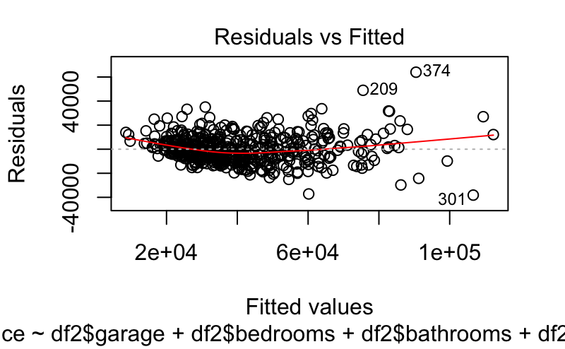

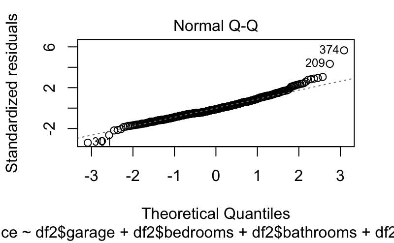

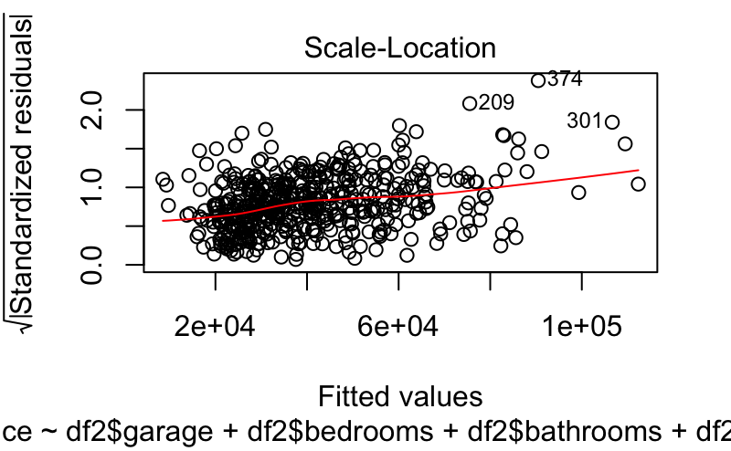

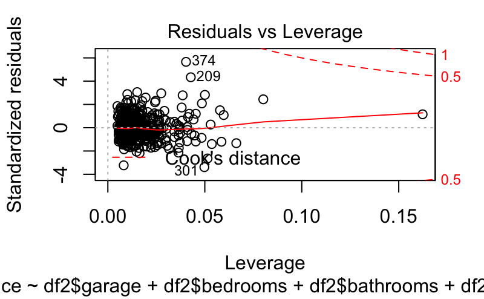

```r
plot(m)
```

```r
result <- anova(m)
r2_gargage <- (result$`Sum Sq`[1])/(sum(result$`Sum Sq`))
VIF_gargage <- 1/(1-r2_gargage)
r2_bedrooms <-(result$`Sum Sq`[2])/(sum(result$`Sum Sq`))
VIF_bedrooms <- 1/(1-r2_bedrooms)
r2_bathrooms <-(result$`Sum Sq`[3])/(sum(result$`Sum Sq`))
VIF_bathrooms <- 1/(1-r2_bathrooms)
r2_datebuilt <-(result$`Sum Sq`[4])/(sum(result$`Sum Sq`))
VIF_datebuilt <- 1/(1-r2_datebuilt)
r2_floorarea <-(result$`Sum Sq`[5])/(sum(result$`Sum Sq`))
VIF_floorarea <- 1/(1-r2_floorarea)
r2_detached <-(result$`Sum Sq`[6])/(sum(result$`Sum Sq`))
VIF_detached <- 1/(1-r2_detached)
r2_fireplace<-(result$`Sum Sq`[7])/(sum(result$`Sum Sq`))
VIF_fireplacee <- 1/(1-r2_fireplace)
c2 <- rbind(VIF_gargage,VIF_bedrooms,VIF_bathrooms,VIF_datebuilt,VIF_floorarea,VIF_detached,VIF_fireplacee)
c1 <- rbind("1","2","3","4","5","6","7")
Vif <- cbind(c1,c2)
colnames(Vif) <- c("Number","VIF")
library(knitr)
kable(Vif)
```

|  | Number | VIF |
| --- | --- | --- |
| VIF_gargage | 1 | 1.45903786903694 |
| VIF_bedrooms | 2 | 1.16066943702094 |
| VIF_bathrooms | 3 | 1.01232064157994 |
| VIF_datebuilt | 4 | 1.01379248153671 |
| VIF_floorarea | 5 | 1.23796808057415 |
| VIF_detached | 6 | 1.02206714156547 |
| VIF_fireplacee | 7 | 1.00406749458681 |

```r
# Multicollinearity will increase the percentage of the model to explain the variation in the outcome
# The slopes of bedrooms and bathrooms are not significant
```